# Homework 3

### Exercise 10

Using the `cabin` variable, extract:

1. Cabin deck (A, B, C, D, E, F, G, or T);
2. Cabin number (0 to 2000);
3. Cabin side (P or S).

Then do the following:

- Drop any observations with a cabin deck of T;
- Bin cabin number into groups of 300 (for example, 0 - 300, 301 - 600, 601- 900, etc.).

```python
# cabin deck is the first letter of each cabin
titanic_cleaned['Deck'] = titanic_cleaned['Cabin'].str[:1]

# cabin number is the numerical part of each cabin
# titanic_cleaned['CabinNumber'] = titanic_cleaned['Cabin'].str.findall(r'\d+\.?\d*')

titanic_cleaned['CabinNumber'] = titanic_cleaned['Cabin'].apply(lambda x: int(''.join(filter(str.isdigit, x))))

# cabin side is the last letter of each cabin
titanic_cleaned['CabinSide'] = titanic_cleaned['Cabin'].str[-1]
```

```python
titanic_cleaned['Deck']
```

```
0       B
1       F
2       A
3       A
4       F
       ..
8688    A
8689    G
8690    G
8691    E
8692    E
Name: Deck, Length: 8494, dtype: object
```

```python
# drop observations with a cabin deck of T
titanic_cleaned = titanic_cleaned[titanic_cleaned['Deck'] != 'T']

# bin cabin numbers into groups of 300
bins = range(titanic_cleaned['CabinNumber'].min(), titanic_cleaned['CabinNumber'].max() + 301, 300)

labels = []
for i in bins[:-1]:
  if i == 0:
    labels.append(f'{i}-{i+300}')
  else:
    labels.append(f'{i+1}-{i+300}')

# use pd.cut() to categorize into bins
titanic_cleaned['CabinBin'] = pd.cut(titanic_cleaned['CabinNumber'], bins=bins, labels=labels, right=True, include_lowest = True)
```

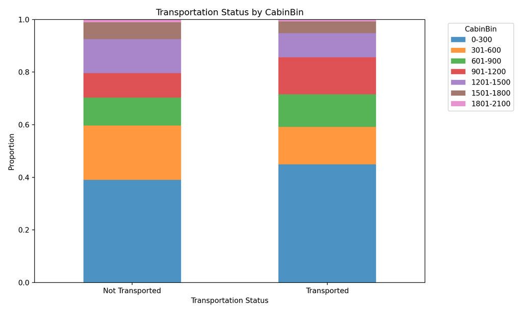

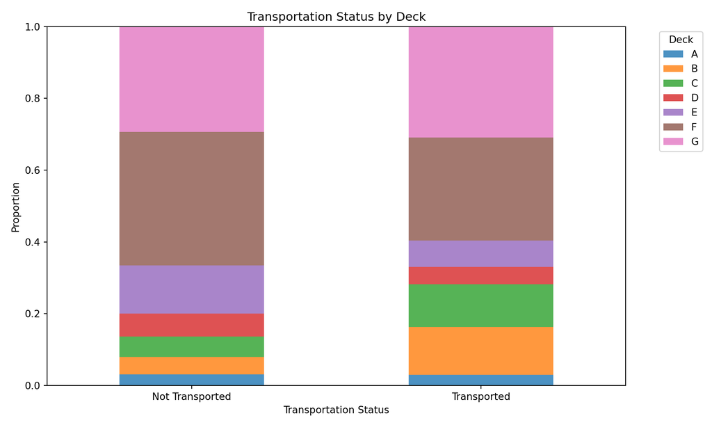

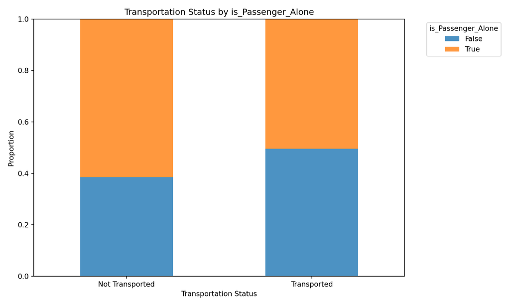

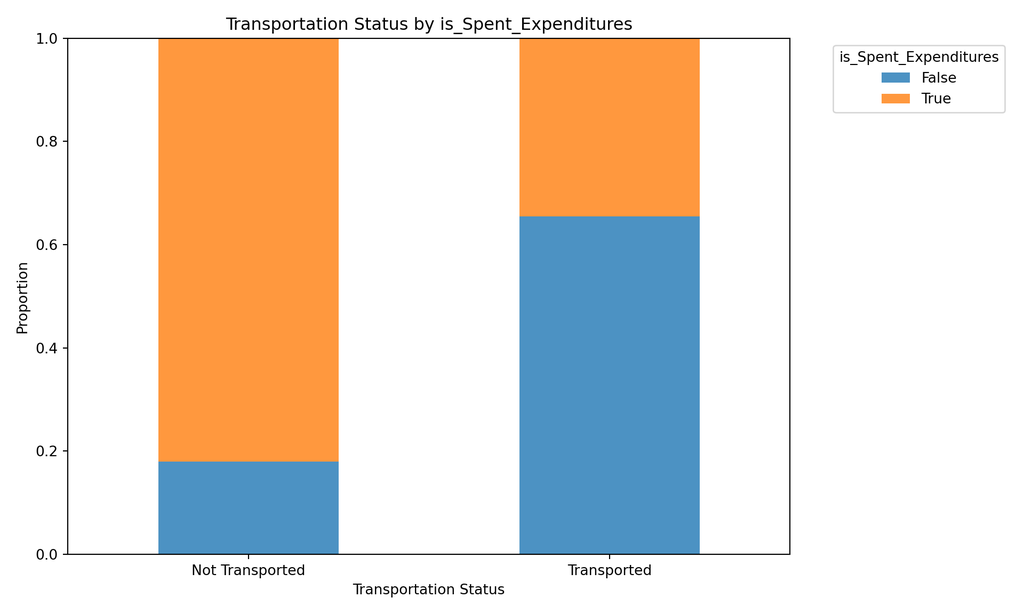

```python
# EXTRA
for i in ['CabinBin', 'Deck', 'is_Passenger_Alone', 'is_Spent_Expenditures']:
  # Calculate counts of each class by home planet
  count_data = titanic_cleaned.groupby(['Transported', i]).size().reset_index(name='count')

  # Calculate the total counts for each home planet
  total_counts = count_data.groupby('Transported')['count'].transform('sum')

  # Calculate the proportion
  count_data['proportion'] = count_data['count'] / total_counts

  # Create a pivot table for better plotting
  pivot_data = count_data.pivot(index='Transported', columns=i, values='proportion').fillna(0)

  # Plotting
  plt.figure(figsize=(10, 6))

  # Stack the bars
  pivot_data.plot(kind='bar', stacked=True, ax=plt.gca(), alpha=0.8)

  # Set y-axis limits
  plt.ylim(0, 1)
  plt.title(f"Transportation Status by {i}", loc = 'center')
  plt.xlabel('Transportation Status')
  plt.xticks(ticks=[0, 1], labels=['Not Transported', 'Transported'], rotation=0)
  plt.ylabel("Proportion")

  # Customize the legend
  plt.legend(title=i, bbox_to_anchor=(1.05, 1), loc='upper left')
  plt.tight_layout()

  # Show the plot
  plt.show()
  plt.close()
```

```python
titanic_cleaned['HomePlanet'].value_counts()
```

```
HomePlanet
Earth     4701
Europa    2066
Mars      1722
Name: count, dtype: int64
```

```python
titanic_cleaned['CryoSleep'].value_counts()
```

```
CryoSleep
False    5536
True     2953
Name: count, dtype: int64
```

```python
titanic_cleaned['VIP'].value_counts()
```

```
VIP
False    8296
True      193
Name: count, dtype: int64
```

```python
titanic_cleaned['CabinBin'].value_counts()
```

```
CabinBin
0-300        3564
301-600      1484
901-1200      991
601-900       976
1201-1500     937
1501-1800     459
1801-2100      78
Name: count, dtype: int64
```

```python
titanic_cleaned['Deck'].value_counts()
```

```
Deck
F    2794
G    2559
E     876
B     779
C     747
D     478
A     256
Name: count, dtype: int64
```

```python
titanic_cleaned['is_Passenger_Alone'].value_counts()
```

```
is_Passenger_Alone
True     4748
False    3741
Name: count, dtype: int64
```

```python
titanic_cleaned['is_Spent_Expenditures'].value_counts()
```

```
is_Spent_Expenditures
True     4933
False    3556
Name: count, dtype: int64
```

### Exercise 11

Create a new data frame (or tibble) that retains the following features:

1. `home_planet`
2. cabin deck
3. cabin number (binned)
4. cabin side
5. `age` (binned)
6. total expenditures (log-transformed)
7. `cryo_sleep`
8. `destination`
9. whether the passenger was traveling alone (call this `solo`)
10. Transported

To those features, do the following:

- One-hot encode all categorical features
- Center and scale all continuous features

```python
titanic_new = pd.DataFrame({'home_planet': titanic_cleaned['HomePlanet'], 'cabin_deck': titanic_cleaned['Deck'], 'cabin_number_bin': titanic_cleaned['CabinBin'], 'age_bin': titanic_cleaned['Age_Group'], 'total_expenditures_log': titanic_cleaned['Sum_Expenditures_log'], 'cryo_sleep': titanic_cleaned['CryoSleep'], 'destination': titanic_cleaned['Destination'], 'solo': titanic_cleaned['is_Passenger_Alone'], 'transported': titanic_cleaned['Transported']})

# alternate
# selected_columns = [
#     'HomePlanet', 'Deck', 'CabinBin', 'Age_Group', 'Sum_Expenditures_log',
#     'CryoSleep', 'Destination', 'is_Passenger_Alone', 'Transported'
# ]
#
# df = titanic_cleaned[selected_columns].copy()
#
# # Rename the columns
# df.columns = [
#     'home_planet', 'cabin_deck', 'cabin_number_bin', 'age_bin',
#     'total_expenditures_log', 'cryo_sleep', 'destination', 'solo', 'transported'
# ]
```

```python
titanic_new_hot = pd.get_dummies(titanic_new.drop(columns = ['total_expenditures_log', 'transported']), drop_first=False)

# Initialize the scaler
scaler = StandardScaler()

# Fit and transform the data (center and scale)
titanic_new_hot['total_expenditures_log_scaled'] = scaler.fit_transform(titanic_new[['total_expenditures_log']])

titanic_new_hot['transported'] = titanic_new['transported']

titanic_new_hot
```

```
      cryo_sleep   solo  ...  total_expenditures_log_scaled  transported
0          False   True  ...                      -1.159492        False
1          False   True  ...                       0.627373         True
2          False  False  ...                       1.343309        False
3          False  False  ...                       1.154939        False
4          False   True  ...                       0.733779         True
...          ...    ...  ...                            ...          ...
8688       False   True  ...                       1.290304        False
8689        True   True  ...                      -1.159492        False
8690       False   True  ...                       0.879937         True
8691       False  False  ...                       1.125185        False
8692       False  False  ...                       1.135995         True

[8489 rows x 29 columns]
```

### Exercise 12

Write up your analyses thus far in one or two paragraphs. Describe what you have learned about the passengers on the Spaceship Titanic. Describe the relationships you observed between variables. Which features do you think may be the best predictors of transported status? Why or why not?

### Exercises for 234 Students

#### Exercise 13

Split the dataset into training and testing. Use random sampling. Make sure that $80\%$ of observations are in the training set and the remaining $20\%$ in the testing set.

#### Exercise 14

Using *k*-fold cross-validation with *k* of 5, tune two models:

1. A random forest;
2. An elastic net.

#### Exercise 15

Select your best **random forest** model and use it to predict your testing set. Present the following:

- Testing accuracy;
- Testing ROC curve (and area under the ROC curve);
- Confusion matrix;
- Variable importance plot.

#### Exercise 16

Write up your conclusions in one to two paragraphs. Answer the following: How did your models do? Are you happy with their performance? Is there another model (besides these two) that you would be interested in trying? Which features ended up being the most important in terms of predicting whether or not a passenger would be transported?